# Mixed Models Workshop - Worksheet 3

Andrew Stewart

```r
library(tidyverse)
library(lme4)
library(lmerTest)
library(emmeans)
```

# One Factor Repeated Measures

Load the dataset “data2.csv” from the worksheet_data folder. These data are from an experiment where we measured how long people spent looking at images that appeared on screen. The images depicted either positive, neutral, or negative scenes. This is our one factor with three levels. The design was repeated measures. Perform the appropriate LMM analysis and determine whether people spent a different amount of time looking at the positive relative to the negative images, and the neutral relative to the negative images.

First we need to set our appropriate factors.

```r
my_data$Subject <- as.factor(my_data$Subject)
my_data$Item <- as.factor(my_data$Item)
my_data$Image <- as.factor(my_data$Image)
```

Let’s visualise our data:

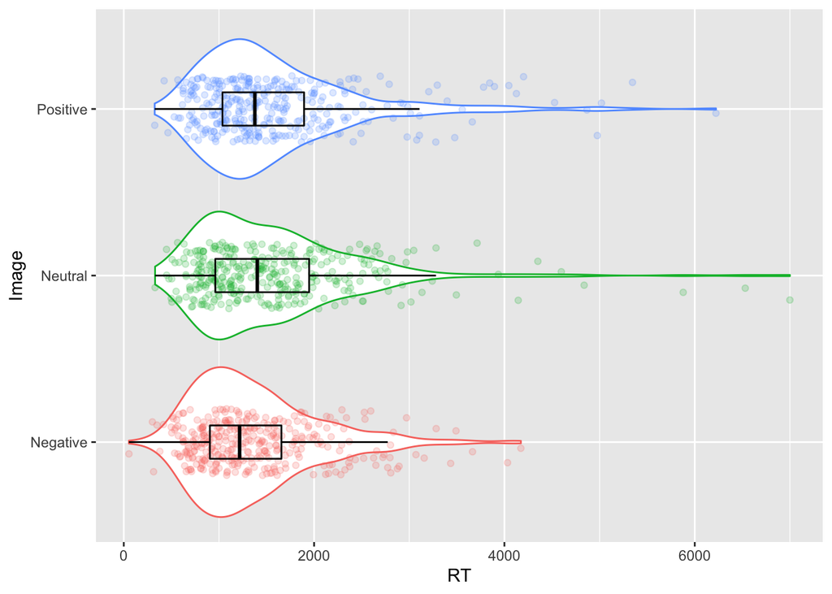

```r
my_data %>%
  ggplot(aes (x = Image, y = RT, colour = Image)) +
  geom_violin() +
  geom_jitter(alpha = .2, width = .2) +
  guides(colour = FALSE) +
  geom_boxplot(width = .2, colour = "black", alpha = 0) +
  coord_flip()
```

We have some missing data so need to use na.rm = TRUE to ignore those points.

```r
my_data %>%
  group_by(Image) %>%
  summarise(mean = mean(RT, na.rm = TRUE), sd = sd(RT, na.rm = TRUE))
```

```
## # A tibble: 3 x 3
##   Image     mean    sd
##   <fct>    <dbl> <dbl>
## 1 Negative 1370.  658.
## 2 Neutral  1563.  864.
## 3 Positive 1591.  855.
```

Let’s build our model.

```r
model <- lmer(RT ~ Image + (1 | Subject) + (1 | Item), data = my_data)
summary(model)
```

```
## Linear mixed model fit by REML. t-tests use Satterthwaite's method [
## lmerModLmerTest]
## Formula: RT ~ Image + (1 | Subject) + (1 | Item)
##    Data: my_data
##
## REML criterion at convergence: 16539.5
##
## Scaled residuals:
##     Min      1Q  Median      3Q     Max
## -2.4166 -0.5898 -0.1799  0.3669  7.1973
##
## Random effects:
##  Groups   Name        Variance Std.Dev.
##  Subject  (Intercept)  86182   293.6
##  Item     (Intercept) 124010   352.2
##  Residual             435698   660.1
## Number of obs: 1038, groups:  Subject, 50; Item, 28
##
## Fixed effects:
##               Estimate Std. Error      df t value Pr(>|t|)
## (Intercept)    1366.88      86.01   56.29  15.892  < 2e-16 ***
## ImageNeutral    198.82      49.96  958.73   3.980 7.42e-05 ***
## ImagePositive   208.55      50.46  960.31   4.133 3.89e-05 ***
## ---
## Signif. codes:  0 '***' 0.001 '**' 0.01 '*' 0.05 '.' 0.1 ' ' 1
##
## Correlation of Fixed Effects:
##             (Intr) ImgNtr
## ImageNeutrl -0.290
## ImagePositv -0.287  0.494
```

How do the residuals look?

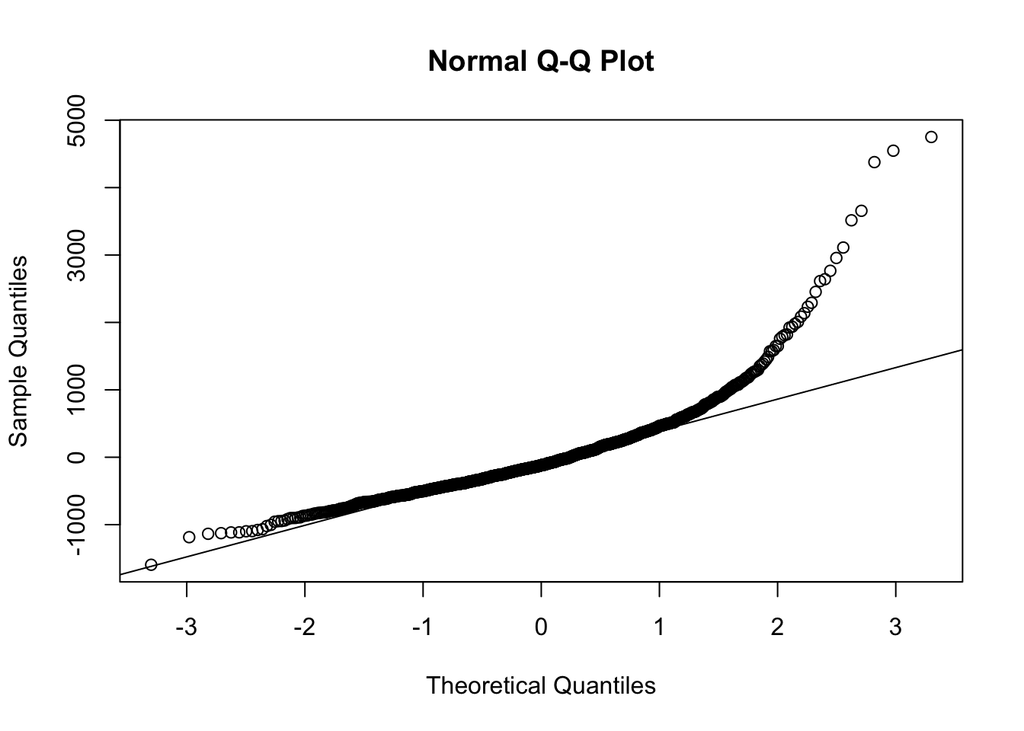

```r
qqnorm(residuals(model))
qqline(residuals(model))
```

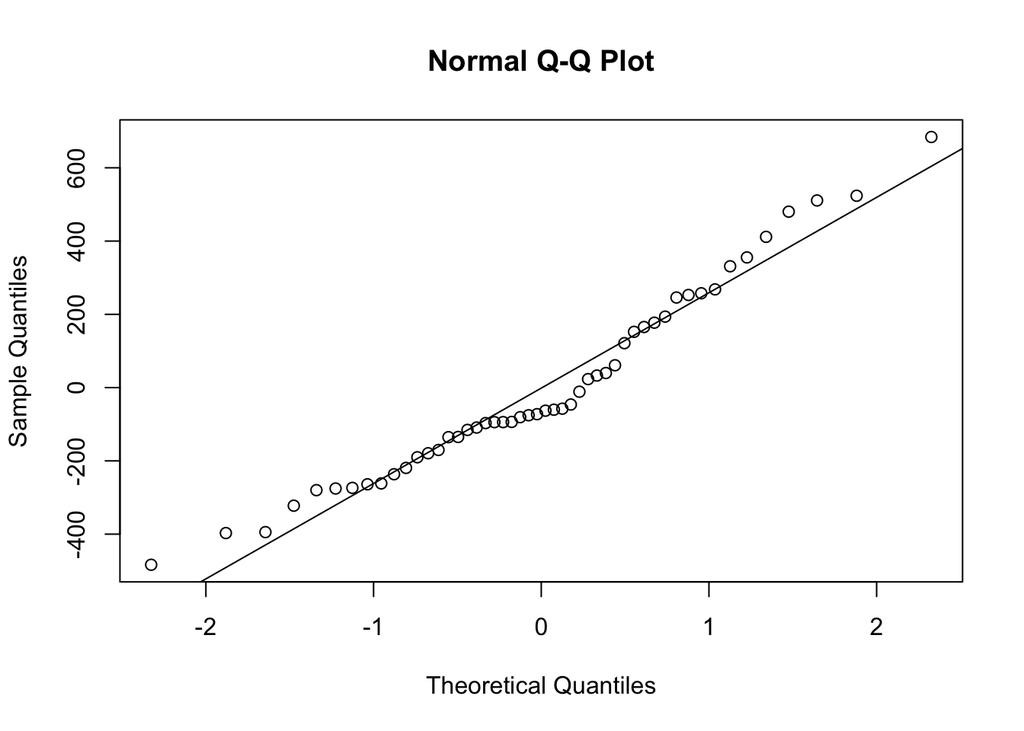

```r
r_int <- ranef(model)$Subject$`(Intercept)`
qqnorm(r_int)
qqline(r_int)
```

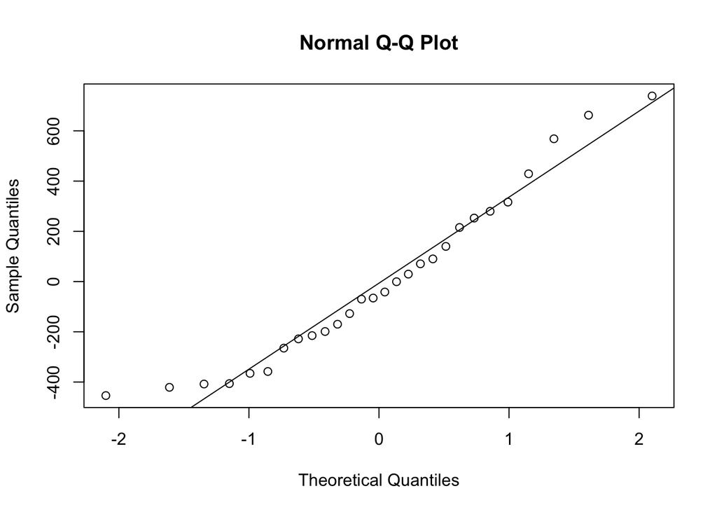

```r
r_int <- ranef(model)$Item$`(Intercept)`
qqnorm(r_int)
qqline(r_int)
```

Let’s look at the distribution of the data.

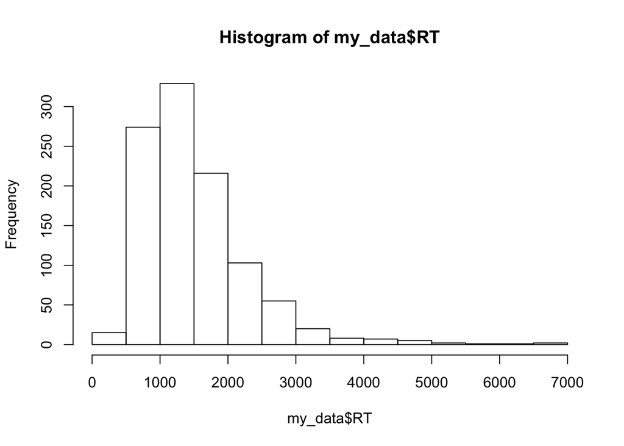

```r
hist(my_data$RT)
```

OK, this looks a little like Gamma distributed data so let’s build a generalised mixed model. Note, that beloow we add the log link function to our model. According to Ben Bolker "When using `lme4` to fit GLMMs with link functions that do not automatically constrain the response to the allowable range of the distributional family (e.g. binomial models with a log link, where the estimated probability can be >1, or inverse-Gamma models, where the estimated mean can be negative), it is not unusual to get the error

```
PIRLS step-halvings failed to reduce deviance in pwrssUpdate
```

This occurs because `lme4` doesn’t do anything to constrain the predicted values, so `NaN` values pop up, which aren’t handled gracefully. If possible, switch to a link function to one that constrains the response (e.g. logit link for binomial or log link for Gamma)."

https://stat.ethz.ch/pipermail/r-sig-mixed-models/2016q1/024453.html

```r
model_gamma <- glmer(RT ~ Image + (1 | Subject) + (1 | Item), data = my_data, family = Gamma(link = log))
summary(model_gamma)
```

```
## Generalized linear mixed model fit by maximum likelihood (Laplace
##   Approximation) [glmerMod]
##  Family: Gamma  ( log )
## Formula: RT ~ Image + (1 | Subject) + (1 | Item)
##    Data: my_data
##
##      AIC      BIC   logLik deviance df.resid
##  16010.6  16040.3  -7999.3  15998.6     1032
##
## Scaled residuals:
##     Min      1Q  Median      3Q     Max
## -2.1899 -0.6266 -0.1829  0.4324  7.6687
##
## Random effects:
##  Groups   Name        Variance Std.Dev.
##  Subject  (Intercept) 0.02597  0.1611
##  Item     (Intercept) 0.02620  0.1619
##  Residual             0.17717  0.4209
## Number of obs: 1038, groups:  Subject, 50; Item, 28
##
## Fixed effects:
##               Estimate Std. Error t value Pr(>|z|)
## (Intercept)    7.15636    0.07571  94.520  < 2e-16 ***
## ImageNeutral   0.14111    0.02809   5.023 5.08e-07 ***
## ImagePositive  0.14145    0.02823   5.011 5.40e-07 ***
## ---
## Signif. codes:  0 '***' 0.001 '**' 0.01 '*' 0.05 '.' 0.1 ' ' 1
##
## Correlation of Fixed Effects:
##             (Intr) ImgNtr
## ImageNeutrl -0.184
## ImagePositv -0.182  0.492
```

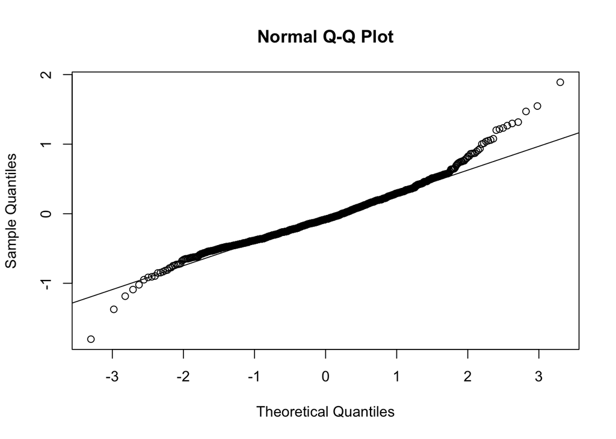

```r
qqnorm(residuals(model_gamma))
qqline(residuals(model_gamma))
```

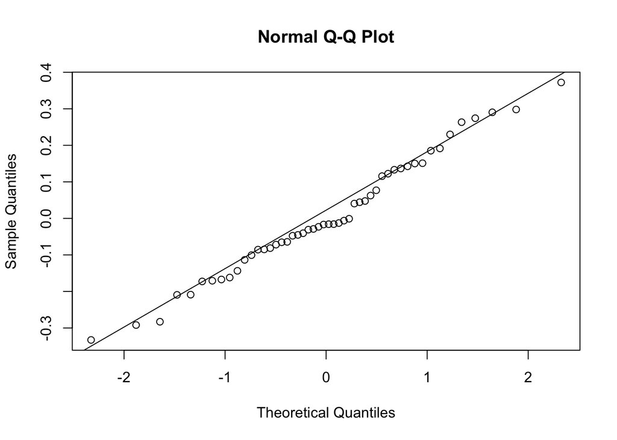

```r
r_int <- ranef(model_gamma)$Subject$`(Intercept)`
qqnorm(r_int)
qqline(r_int)
```

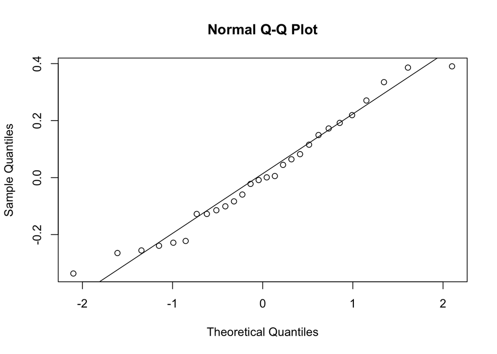

```r
r_int <- ranef(model_gamma)$Item$`(Intercept)`
qqnorm(r_int)
qqline(r_int)
```

This looks better - let’s generate the summary of the model.

```r
summary(model_gamma)
```

```
## Generalized linear mixed model fit by maximum likelihood (Laplace
##   Approximation) [glmerMod]
##  Family: Gamma  ( log )
## Formula: RT ~ Image + (1 | Subject) + (1 | Item)
##    Data: my_data
##
##      AIC      BIC   logLik deviance df.resid
##  16010.6  16040.3  -7999.3  15998.6     1032
##
## Scaled residuals:
##     Min      1Q  Median      3Q     Max
## -2.1899 -0.6266 -0.1829  0.4324  7.6687
##
## Random effects:
##  Groups   Name        Variance Std.Dev.
##  Subject  (Intercept) 0.02597  0.1611
##  Item     (Intercept) 0.02620  0.1619
##  Residual             0.17717  0.4209
## Number of obs: 1038, groups:  Subject, 50; Item, 28
##
## Fixed effects:
##               Estimate Std. Error t value Pr(>|z|)
## (Intercept)    7.15636    0.07571  94.520  < 2e-16 ***
## ImageNeutral   0.14111    0.02809   5.023 5.08e-07 ***
## ImagePositive  0.14145    0.02823   5.011 5.40e-07 ***
## ---
## Signif. codes:  0 '***' 0.001 '**' 0.01 '*' 0.05 '.' 0.1 ' ' 1
##
## Correlation of Fixed Effects:
##             (Intr) ImgNtr
## ImageNeutrl -0.184
## ImagePositv -0.182  0.492
```

It looks like both the Neutral and Positive conditions take longer to read than the Negative one. For the Neutral vs. Positive comparison, we need to re-level our factor or conduct pairwise comparisons.

```r
emmeans(model_gamma, pairwise ~ Image)
```

```
## $emmeans
##  Image    emmean     SE  df asymp.LCL asymp.UCL
##  Negative   7.16 0.0757 Inf      7.01      7.30
##  Neutral    7.30 0.0757 Inf      7.15      7.45
##  Positive   7.30 0.0758 Inf      7.15      7.45
##
## Results are given on the log (not the response) scale.
## Confidence level used: 0.95
##
## $contrasts
##  contrast            estimate     SE  df z.ratio p.value
##  Negative - Neutral  -0.14111 0.0281 Inf -5.023  <.0001
##  Negative - Positive -0.14145 0.0282 Inf -5.011  <.0001
##  Neutral - Positive  -0.00034 0.0284 Inf -0.012  0.9999
##
## Results are given on the log (not the response) scale.
## P value adjustment: tukey method for comparing a family of 3 estimates
```

# 2 x 2 Factorial Design

Now we’re going to import the dataset “data3.csv”. These data are from a repeated measures experiment where participants had to respond to a target word (measured by our DV which is labelled “Time”). The target word always followed a prime word. Prime and Target are our two factors – each with two levels – Positive vs. Negative. We are interested in whether there is a priming effect (i.e., Positive target words responded to more quickly after Positive than after Negative Primes, and Negative target words responded to more quickly after Negative than after Positive Primes). We need to build the appropriate LMM to determine whether this is indeed correct.

```r
my_data <- read_csv("worksheet_data/data3.csv")
```

First we need to create our factors:

```r
my_data$Subject <- as.factor(my_data$Subject)
my_data$Item <- as.factor(my_data$Item)
my_data$Prime <- as.factor(my_data$Prime)
my_data$Target <- as.factor(my_data$Target)
```

As it is a factorial experiment, we need to set up our contrast weightings for our two factors. This allows for easier intepretation of the paramester estimates - the intercept will correspond to the Grand Mean (i.e., the mean of our conditions).

```r
contrasts(my_data$Prime) <- matrix(c(.5, -.5))
contrasts(my_data$Target) <- matrix(c(.5, -.5))
```

We can now check the structure of our data:

```r
str(my_data)
```

```
## Classes 'spec_tbl_df', 'tbl_df', 'tbl' and 'data.frame': 1280 obs. of  5 variables:
##  $ Subject: Factor w/ 40 levels "1","2","3","4",..: 1 1 1 1 1 1 1 1 1 1 ...
##  $ Item   : Factor w/ 32 levels "1","2","3","4",..: 3 7 11 15 19 23 27 31 4 8 ...
##  $ Time   : num  407 367 352 293 227 497 410 257 203 656 ...
##  $ Prime  : Factor w/ 2 levels "Negative","Positive": 1 1 1 1 1 1 1 1 1 1 ...
##   ..- attr(*, "contrasts")= num [1:2, 1] 0.5 -0.5
##   .. ..- attr(*, "dimnames")=List of 2
##   .. .. ..$ : chr  "Negative" "Positive"
##   .. .. ..$ : NULL
##  $ Target : Factor w/ 2 levels "Negative","Positive": 1 1 1 1 1 1 1 1 2 2 ...
##   ..- attr(*, "contrasts")= num [1:2, 1] 0.5 -0.5
##   .. ..- attr(*, "dimnames")=List of 2
##   .. .. ..$ : chr  "Negative" "Positive"
##   .. .. ..$ : NULL
##  - attr(*, "spec")=
##   .. cols(
##   ..   Subject = col_double(),
##   ..   Item = col_double(),
##   ..   Time = col_double(),
##   ..   Prime = col_character(),
##   ..   Target = col_character()
##   .. )
```

Let’s visualise our data:

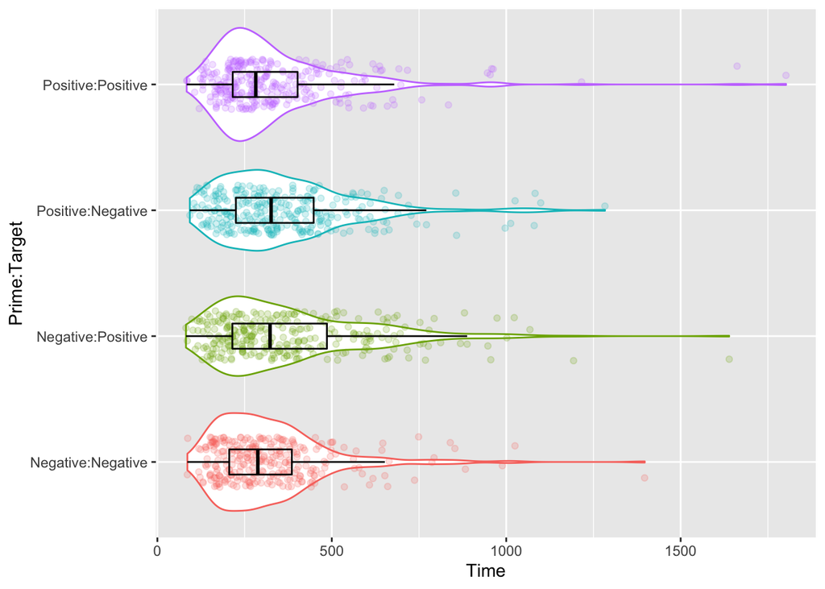

```r
my_data %>%
  ggplot(aes(x = Prime:Target, y = Time, colour = Prime:Target)) +
  geom_violin() +
  geom_jitter(alpha = .2, width = .2) +
  guides(colour = FALSE) +
  geom_boxplot(width = .2, colour = "black", alpha = 0) +
  coord_flip()
```

Now we are going to generate some descriptives, filtering out cases where we have missing data in our dependent variable (labelled “Time”).

```r
my_data %>%
  filter(!is.na(Time)) %>%
  group_by(Prime, Target) %>%
  summarise(mean = mean(Time), sd = sd(Time))
```

```
## # A tibble: 4 x 4
## # Groups:   Prime [2]
##   Prime    Target    mean    sd
##   <fct>    <fct>    <dbl> <dbl>
## 1 Negative Negative  321.  167.
## 2 Negative Positive  376.  219.
## 3 Positive Negative  361.  191.
## 4 Positive Positive  337.  203.
```

```r
my_data %>% filter(is.na(Time))
```

```
## # A tibble: 121 x 5
##    Subject Item   Time Prime    Target
##    <fct>   <fct> <dbl> <fct>    <fct>
##  1 1       29       NA Positive Positive
##  2 4       27       NA Negative Negative
##  3 4       24       NA Negative Positive
##  4 5       24       NA Negative Positive
##  5 5       30       NA Positive Negative
##  6 6       19       NA Negative Negative
##  7 6       12       NA Negative Positive
##  8 6       14       NA Positive Negative
##  9 7       3        NA Negative Negative
## 10 7       11       NA Negative Negative
## # … with 111 more rows
```

Note we have a little missing data (121 rows) - not a big deal, but something that you could report.

We could calculate and plot the amount of missing data per participant:

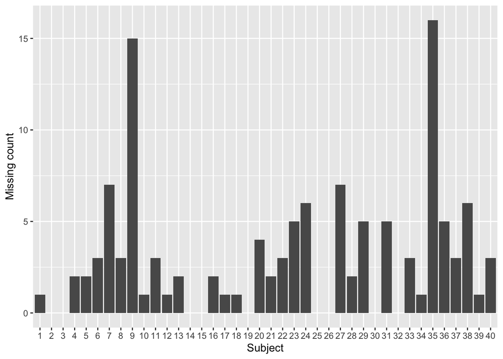

```r
my_data %>%
  group_by(Subject) %>%
  summarise(missing_count = sum(is.na(Time))) %>%
  ggplot(aes(x = Subject, y = missing_count)) +
  geom_col() +
  labs(y = "Missing count")
```

```r
model <- lmer(Time ~ Prime * Target + (1 + Prime * Target | Subject) + (1 + Prime * Target | Item), data = my_data)
```

```
## boundary (singular) fit: see ?isSingular
```

```r
summary(model)
```

```
## Linear mixed model fit by REML. t-tests use Satterthwaite's method [
## lmerModLmerTest]
## Formula: Time ~ Prime * Target + (1 + Prime * Target | Subject) + (1 +
##     Prime * Target | Item)
##    Data: my_data
##
## REML criterion at convergence: 15336.5
##
## Scaled residuals:
##     Min      1Q  Median      3Q     Max
## -3.0618 -0.6053 -0.1849  0.4015  6.4724
##
## Random effects:
##  Groups   Name           Variance Std.Dev. Corr
##  Subject  (Intercept)     6088.4   78.03
##           Prime1           801.7   28.32    0.23
##           Target1         2158.4   46.46   -0.55 -0.94
##           Prime1:Target1   294.1   17.15   -0.57  0.66 -0.37
##  Item     (Intercept)     1438.9   37.93
##           Prime1           146.8   12.12   -1.00
##           Target1          137.2   11.71   -1.00  1.00
##           Prime1:Target1   342.1   18.50   -1.00  1.00  1.00
##  Residual                30111.8  173.53
## Number of obs: 1159, groups:  Subject, 40; Item, 32
##
## Fixed effects:
##                 Estimate Std. Error        df t value Pr(>|t|)
## (Intercept)    344.37768   14.95496  51.24156  23.028  < 2e-16 ***
## Prime1          -0.03613   11.36706  68.03416  -0.003  0.99747
## Target1        -15.26519   12.77002  47.74892  -1.195  0.23784
## Prime1:Target1 -77.24959   20.88072 229.10990  -3.700  0.00027 ***
## ---
## Signif. codes:  0 '***' 0.001 '**' 0.01 '*' 0.05 '.' 0.1 ' ' 1
##
## Correlation of Fixed Effects:
##             (Intr) Prime1 Targt1
## Prime1      -0.006
## Target1     -0.330 -0.179
## Prim1:Trgt1 -0.129  0.068  0.005
## convergence code: 0
## boundary (singular) fit: see ?isSingular
```

This suggests our model is over-parameterised - the “singular fit” message tells us we have combinations of our effects where some dimensions of the variance-covariance matrix in our model are effectively zero. In other words, we are trying to estimate more parameters than our data will allow. In practice you might want to simplify your random effects structure until you find a model that isn’t over parameterised. For the time being, let’s stick with this model.

Our interaction is significant - we now need to run pairwise comparisons to figure out what condition(s) differs from what other condition(s). We need to use the emmeans() function from the emmeans package - let’s do the correction manually as only a couple of pairwise comparisons make theoretical sense. They are Positive/Positive vs Negative/Positive, and Negative/Negative vs Positive/Negative. These are the only pairs where we’re comparing the same target to the same target under the two different levels of our prime. So, we need to multiply by 2 the calculated p-values for these comparisons to correct for familywise error.

```r
emmeans(model, pairwise ~ Prime * Target, adjust = "none")
```

```
## $emmeans
##  Prime    Target   emmean   SE   df lower.CL upper.CL
##  Negative Negative    317 15.2 32.1      286      348
##  Positive Negative    356 17.3 38.1      321      391
##  Negative Positive    371 20.4 41.4      330      412
##  Positive Positive    333 18.7 40.6      295      371
##
## Degrees-of-freedom method: kenward-roger
## Confidence level used: 0.95
##
## $contrasts
##  contrast                              estimate   SE   df t.ratio p.value
##  Negative,Negative - Positive,Negative    -38.7 16.0 20.1 -2.416  0.0253
##  Negative,Negative - Negative,Positive    -53.9 16.6 21.6 -3.249  0.0038
##  Negative,Negative - Positive,Positive    -15.3 15.6 19.0 -0.983  0.3381
##  Positive,Negative - Negative,Positive    -15.2 18.6 25.9 -0.820  0.4199
##  Positive,Negative - Positive,Positive     23.4 16.5 21.6  1.416  0.1710
##  Negative,Positive - Positive,Positive     38.6 15.0 17.6  2.581  0.0190
##
## Degrees-of-freedom method: kenward-roger
```

What do the residuals look like?

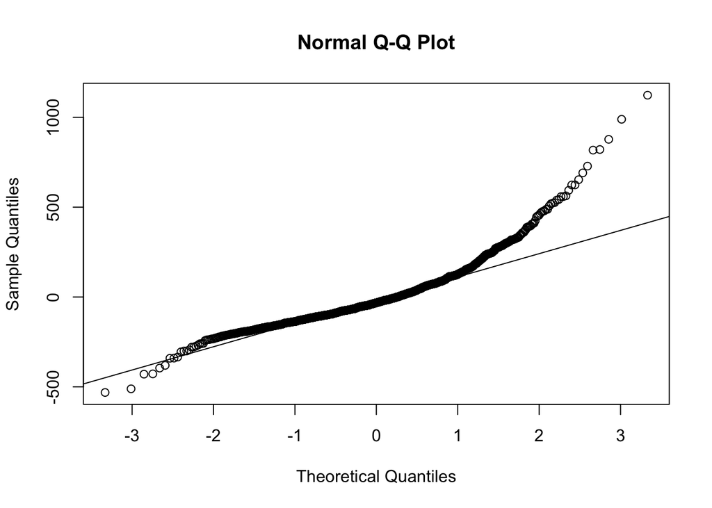

```r
qqnorm(residuals(model))
qqline(residuals(model))
```

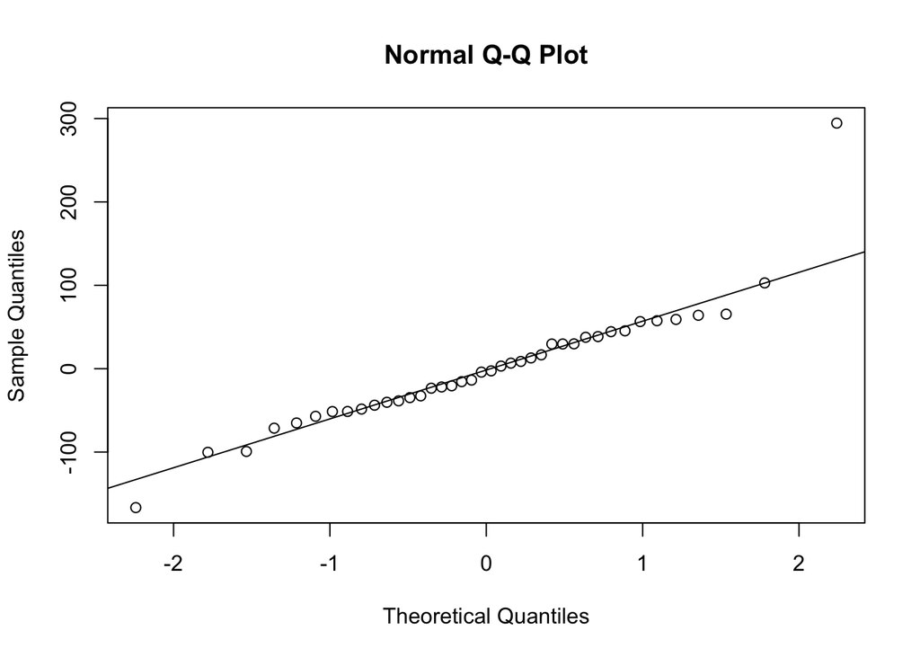

```r
r_int <- ranef(model)$Subject$`(Intercept)`
qqnorm(r_int)
qqline(r_int)
```

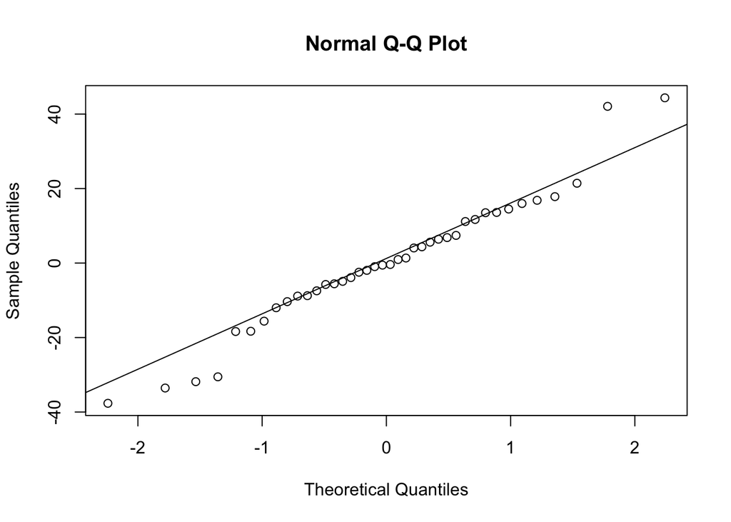

```r
r_int <- ranef(model)$Subject$Prime1
qqnorm(r_int)
qqline(r_int)
```

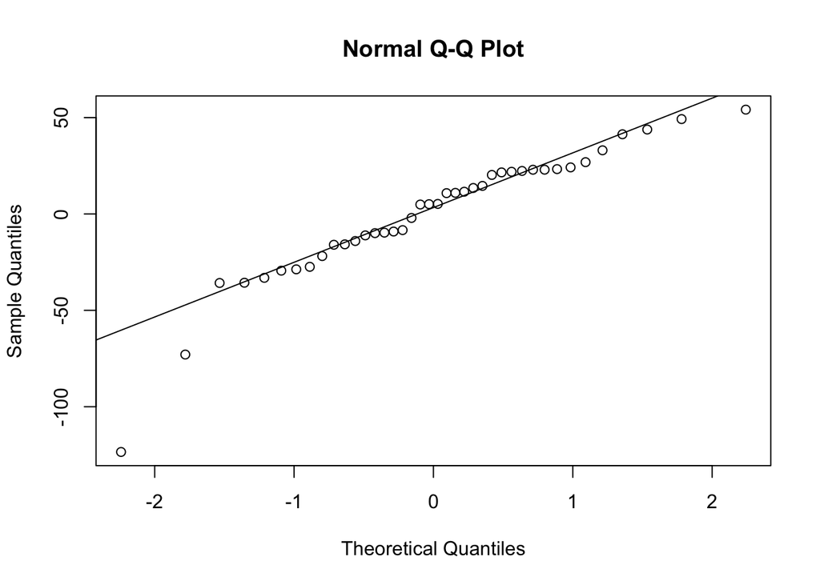

```r
r_int <- ranef(model)$Subject$Target1
qqnorm(r_int)
qqline(r_int)
```

Our power is pretty marginal in this study - as a rule of thumb, we need around 1600 observations per condition to detect the kinds of effect sizes we’re looking for.

[figure not shown]

Brysbaert, M. & Stevens, M. (2018). Power Analysis and Effect Size in Mixed Effects Models: A Tutorial. *Journal of Cognition, 1*, 1–20, DOI: https://doi.org/10.5334/joc.10

How many observations did we have per condition?

```r
my_data %>% group_by(Prime, Target) %>% summarise(count = n())
```

```
## # A tibble: 4 x 3
## # Groups:   Prime [2]
##   Prime    Target   count
##   <fct>    <fct>    <int>
## 1 Negative Negative   320
## 2 Negative Positive   320
## 3 Positive Negative   320
## 4 Positive Positive   320
```

We need to run a much higher powered experiment - we need to increase the number of participants, the number of trials, or both!

What about calculating the Bayes factor in support of the experimental vs. the null hypothesis?